# Project 1

After taking the data of the stock of a certain company, I was able to plot it from 2010 to 2020 to show its fluctuations

```r
library(quantmod)
getSymbols("K.TO", from = "2010/12/31", to = "2020/12/31")
```

```
## [1] "K.TO"
```

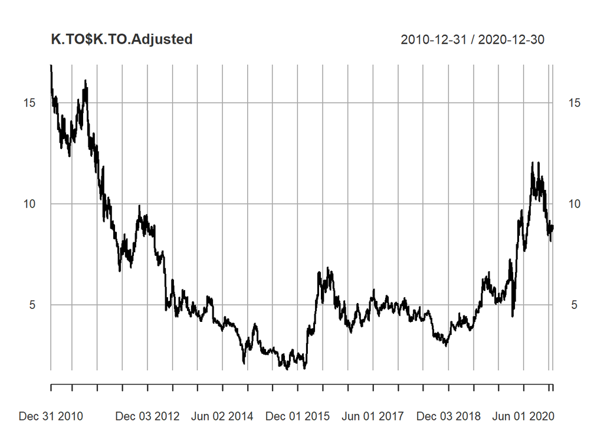

```r
plot(K.TO$K.TO.Adjusted)
```

Calculating and plotting the logarithmic returns

```r
quantmod::dailyReturn(K.TO, type = "log")
```

```
##            daily.returns
## 2010-12-31   0.005302260
## 2011-01-04  -0.041571464
## 2011-01-05  -0.022297447
## 2011-01-06  -0.018777219
## 2011-01-07  -0.003452217
## 2011-01-10  -0.008101971
## 2011-01-11   0.017852555
## 2011-01-12   0.002849773
## 2011-01-13  -0.030042726
## 2011-01-14  -0.025543319
##        ...
## 2020-12-15   0.028044463
## 2020-12-16   0.025124259
## 2020-12-17   0.033937476
## 2020-12-18  -0.023207821
## 2020-12-21   0.028408060
## 2020-12-22  -0.034832008
## 2020-12-23   0.021254764
## 2020-12-24  -0.005271514
## 2020-12-29  -0.006362738
## 2020-12-30   0.025211496
```

```r
diff(log(K.TO))
```

```
##                K.TO.Open    K.TO.High     K.TO.Low   K.TO.Close K.TO.Volume
## 2010-12-31            NA           NA           NA           NA          NA
## 2011-01-04 -0.0112270137 -0.017558309 -0.054748207 -0.041571464  1.59688777
## 2011-01-05 -0.0322344293 -0.033845968 -0.002817761 -0.022297447 -0.23679578
## 2011-01-06 -0.0139784214 -0.011167105 -0.019373835 -0.018777219 -0.08282027
## 2011-01-07 -0.0245096511 -0.009591051 -0.008668048 -0.003452217  0.16003420
## 2011-01-10  0.0097617816 -0.007396857 -0.005820761 -0.008101971 -0.14039535
## 2011-01-11 -0.0011435369  0.003420725  0.011030622  0.017852555  0.08441628
## 2011-01-12  0.0005719319  0.002841783 -0.001155428  0.002849773 -0.03966013
## 2011-01-13  0.0051326120 -0.000567711 -0.019848881 -0.030042726 -0.12966217
## 2011-01-14 -0.0394482886 -0.034077807 -0.022660431 -0.025543319  0.04131424
##        ...
## 2020-12-15 -0.0077221176  0.014184543  0.024832005  0.028044463 -0.03851510
## 2020-12-16  0.0186511255  0.009703597 -0.010084136  0.025124259  0.54736883
## 2020-12-17  0.0362900181  0.049198857  0.054778205  0.033937476 -0.37211976
## 2020-12-18  0.0104276628 -0.002044940 -0.008565355 -0.023207821  1.01805143
## 2020-12-21  0.0031071731  0.007139214  0.020224168  0.028408060 -1.19657428
## 2020-12-22  0.0010336155 -0.008163303 -0.035392426 -0.034832008  0.14650928
## 2020-12-23 -0.0357556642 -0.022798942  0.018388845  0.021254764 -0.60234046
## 2020-12-24  0.0148779994  0.005227423  0.005344769 -0.005271514 -0.51327132
## 2020-12-29 -0.0074113306 -0.005227423 -0.007490639 -0.006362738  0.65942566
## 2020-12-30  0.0000000000  0.014568451  0.009620512  0.025211496 -0.25180228
##            K.TO.Adjusted
## 2010-12-31            NA
## 2011-01-04  -0.041571391
## 2011-01-05  -0.022297136
## 2011-01-06  -0.018777274
## 2011-01-07  -0.003452285
## 2011-01-10  -0.008101964
## 2011-01-11   0.017852536
## 2011-01-12   0.002849675
## 2011-01-13  -0.030042679
## 2011-01-14  -0.025543302
##        ...
## 2020-12-15   0.028044651
## 2020-12-16   0.025124440
## 2020-12-17   0.033937376
## 2020-12-18  -0.023207832
## 2020-12-21   0.028408234
## 2020-12-22  -0.034832511
## 2020-12-23   0.021254993
## 2020-12-24  -0.005271355
## 2020-12-29  -0.006362962
## 2020-12-30   0.025211834
```

```r
print('We get the same output with the first order differencing in K.TO.Close')
```

```
## [1] "We get the same output with the first order differencing in K.TO.Close"
```

By plotting the ACF, we can see that it is uncorrelated

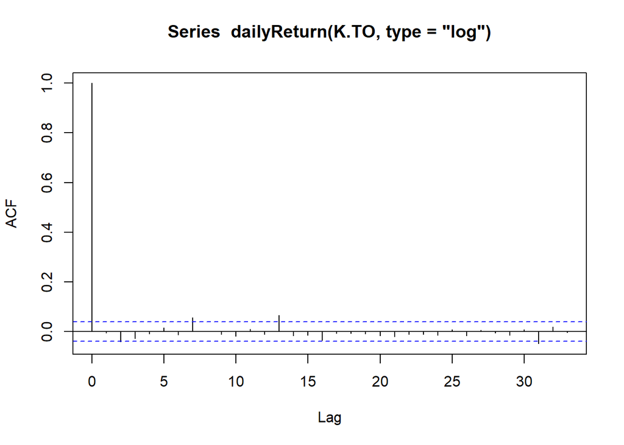

```r
acf(dailyReturn(K.TO, type = "log"))
```

```r
print("We know that if a ACF shows 95% of autocorrelations to fall whitin the +-2sqrt(n) SD, then it is a WN and uncorrelated, as seen below")
```

```
## [1] "We know that if a ACF shows 95% of autocorrelations to fall whitin the +-2sqrt(n) SD, then it is a WN and uncorrelated, as seen below"
```

4. [4 marks] Consider what would happen if the returns were predictable, let’s say following an MA(1) model $R_t = \mu + V_t + .5 V_{t-1}$, where $V_t \sim ^{iid} N(0,\sigma_v^2)$. First, estimate the values of $\mu$ and $\sigma_v^2$ based on the mean and variance of your stock’s daily returns, by setting $\mu = \bar{R}$ and $\sigma_v^2 = S_R^2 / 1.25$, where $\bar{R},S_R^2$ are the sample mean and variance of the returns. (If you are wondering about the division by 1.25, remember that for the MA(1) model $X_t = W_t + \theta W_{t-1}$ we have $V[X_t]=(1+\theta^2) \sigma^2_w$.)